# Perfiles químicos y estrategias de interacción de Bagheera kiplingi con el mutualismo Vachellia-Pseudomyrmex

septiembre 23, 2026

## Introducción

- Mutualismo obligado: Sistema *Vachellia - Pseudomyrmex* → Recompensa nutricional + Defensa contra hervíboros
- Complejidad a la interacción por especies oportunitas → *Bagheera kiplingi* dieta - cuerpos de belt 90%

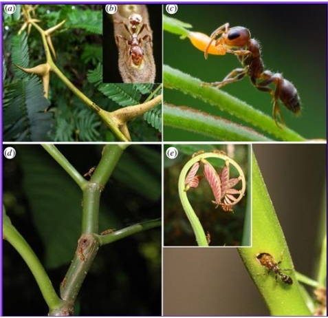

- Transición trófica en *B. kiplingi*
- Modelo complejo → Ecología química y comportamental
  - Estrategias de interacción
  - Señales químicas
  - Estrategias adicionales de comportamiento

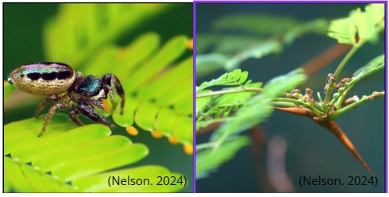

## Planteamiento del Problema

## Pegunta

¿Cuáles son los principales hidrocarburos cuticulares producidos por *Bagheera kiplingi* que median la interacción con *Pseudomyrmex* sp.?

## Hipótesis

La coexistencia de *B. kiplingi* en plantas con colonias de *Pseudomyrmex* sp. está facilitada por una estrategia de semejanza en los perfiles de hidrocarburos cuticulares (CHCs), donde la composición química de la araña presenta correlación con el perfil químico de su hormiga hospedera (mimetismo agresivo) o con la planta (camuflaje), permitiendo así su integración en el ambiente y la reducción de respuestas agresivas.

## Objetivos

## Objetivo general

Caracterizar los hidrocarburos cuticulares de *B. kiplingi* e investigar el papel ecológico potencial de estos compuestos en la señalización química frente a las hormigas *Pseudomyrmex* sp. en asociación con *Vachellia* sp.

## Objetivos específicos

1. Identificar el perfil químico de los CHCs de *B. kiplingi* mediante cromatografía de gases acoplada a espectrometría de masas (GC-MS).
2. Comparar los CHCs de B. kiplingi con los CHCs de *Pseudomyrmex* sp. y cuerpos de Belt de *Vachellia* sp. Para detectar similitudes o diferencias en el comportamiento.
3. Analizar la interacción araña-hormiga mediante bioensayos olfativos con extractos de CHCs de *B.kiplingi*.

## Métodos

## Fase 1

[figure not shown]

## Fase 2

[figure not shown]